# Lab 7 - So what if you smoke when pregnant?

# Baby weight vs. smoking

Consider the possible relationship between a mother’s smoking habit and the weight of her baby. Plotting the data is a useful first step because it helps us quickly visualize trends, identify strong associations, and develop research questions.

6. Make side-by-side boxplots displaying the relationship between `habit` and `weight`. What does the plot highlight about the relationship between these two variables?

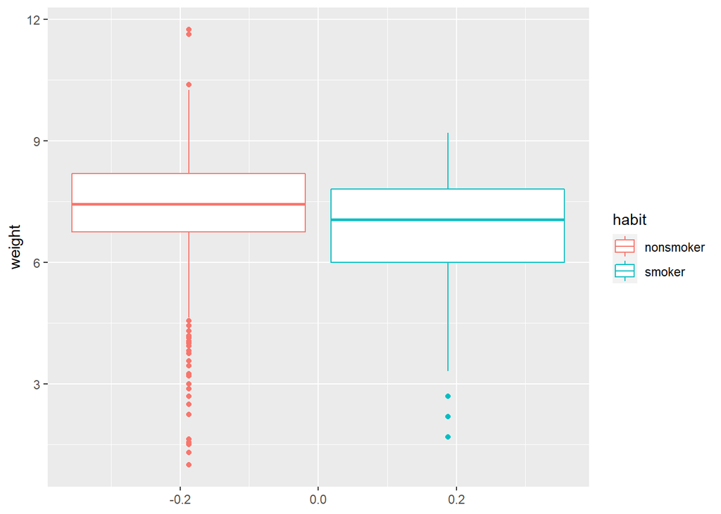

```r
ncbirths_white %>%
  filter(!is.na(habit)) %>%
  ggplot(aes(y = weight, color = habit)) +
  geom_boxplot()
```

```r
# smokers have babies with lower birth weight
```

7. Before moving forward, save a version of the dataset omitting observations where there are NAs for `habit`. You can call this version `ncbirths_habitgiven`.

```r
ncbirths_habitgiven <- ncbirths_white %>% filter(!is.na(habit))
```

The box plots show how the medians of the two distributions compare, but we can also compare the means of the distributions using the following to first group the data by the `habit` variable, and then calculate the mean `weight` in these groups using.

```r
ncbirths_habitgiven %>%
  group_by(habit) %>%
  summarise(mean_weight = mean(weight))
```

[output not shown]

There is an observed difference, but is this difference statistically significant? In order to answer this question we will conduct a hypothesis test .

7. Write the hypotheses for testing if the average weights of babies born to smoking and non-smoking mothers are different.

H0: the average weights of babies born to smoking and non-smoking mothers are equal. Ha: the average weights of babies born to smoking and non-smoking mothers are different.

8. Are the conditions necessary for conducting simulation based inference satisfied? Explain your reasoning.

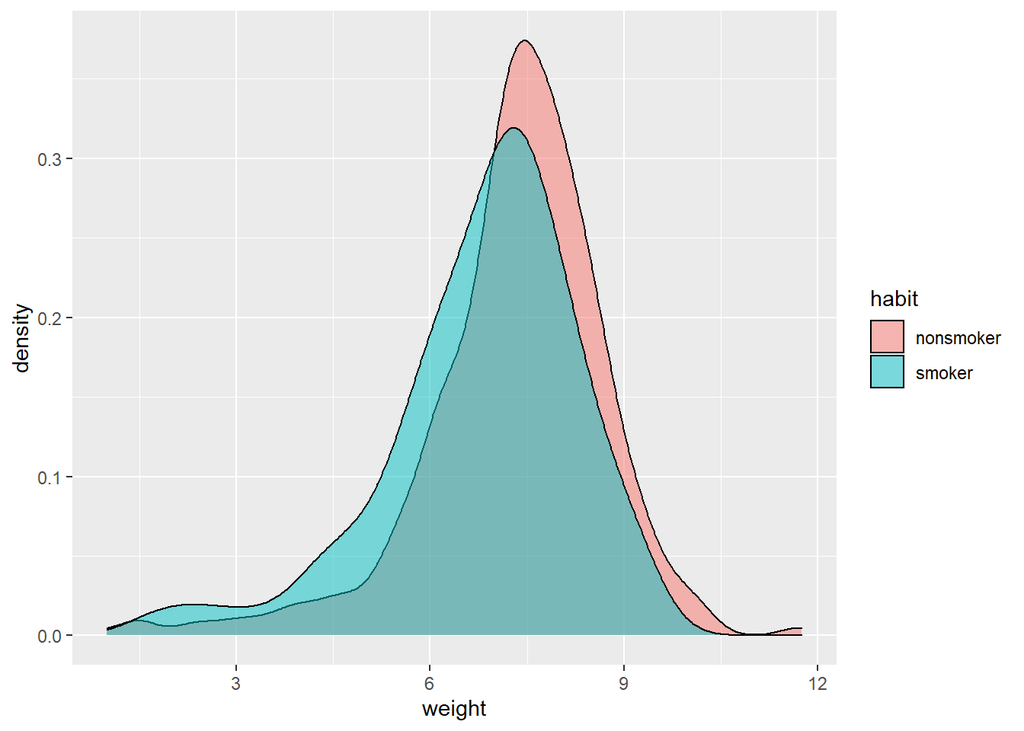

```r
ncbirths_white %>%
  filter(!is.na(habit)) %>%
  ggplot(aes(x = weight, fill = habit)) +
  geom_density(alpha = .5)
```

```r
# no obvious differences in variance
```

9. Run the appropriate hypothesis test, calculate the p-value, and interpret the results in context of the data and the hypothesis test.

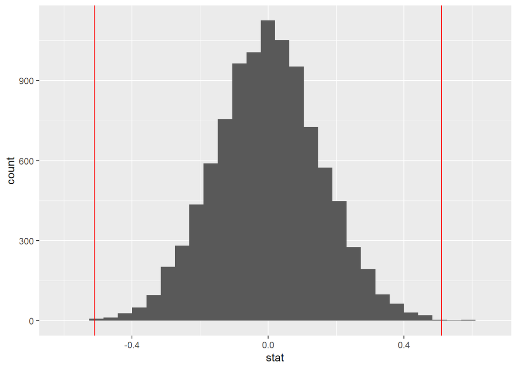

```r
boot_means <- ncbirths_habitgiven%>%
  specify(response = weight, explanatory = habit) %>%
  hypothesize(null = "independence") %>% # shift step: adding 7.43-7.25 to every bootstrap
  generate(reps = 10000, type = "permute") %>%
  calculate(stat = "diff in means", order = c("nonsmoker", "smoker"))

ggplot(data = boot_means, aes(x = stat)) +
  geom_histogram() +
  geom_vline(xintercept = -.51, color = "red") +
  geom_vline(xintercept = .51, color = "red")
```

```r
m <- ncbirths_habitgiven %>%
  group_by(habit) %>%
  summarise(mean_weight = mean(weight))
m$mean_weight[1] - m$mean_weight[2]
```

```
## [1] 0.51
```

```r
a <- boot_means %>%
  filter(stat >= .512)
nrow(a)
```

```
## [1] 6
```

```r
a %>%
  summarise(p_value = n() / 1000)
```

```
## # A tibble: 1 x 1
##   p_value
##     <dbl>
## 1   0.006
```

10. Construct a 95% confidence interval for the difference between the average weights of babies born to smoking and non-smoking mothers.

```r
boot_means <- ncbirths_habitgiven%>%
  specify(response = weight, explanatory = habit) %>%
  generate(reps = 10000, type = "bootstrap") %>%
  calculate(stat = "diff in means", order = c("nonsmoker", "smoker"))

boot_means %>%
  summarize(lower_bound = quantile(stat, 0.025),
            upper_bound = quantile(stat, 0.975))
```

```
## # A tibble: 1 x 2
##   lower_bound upper_bound
##         <dbl>       <dbl>
## 1       0.205       0.839
```

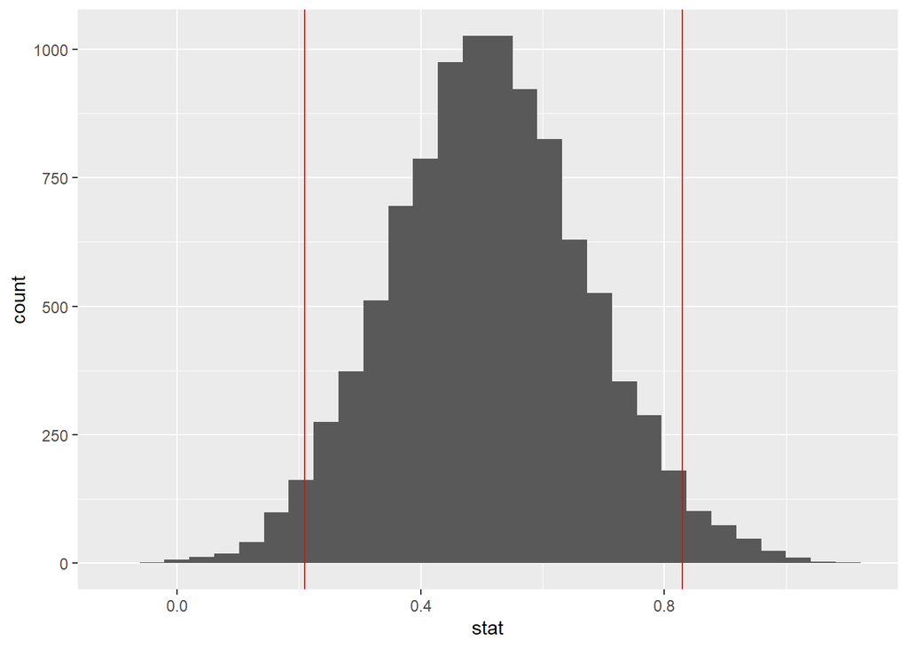

```r
ggplot(data = boot_means, aes(x = stat)) +
  geom_histogram() +
  geom_vline(xintercept = .210, color = "red") +
  geom_vline(xintercept = .829, color = "red")
```

```r
# zero is outside the confidence interval: there is a difference
```

# Baby weight vs. mother’s age

11. First, a non-inference task: Determine the age cutoff for younger and mature mothers. Use a method of your choice, and explain how your method works.

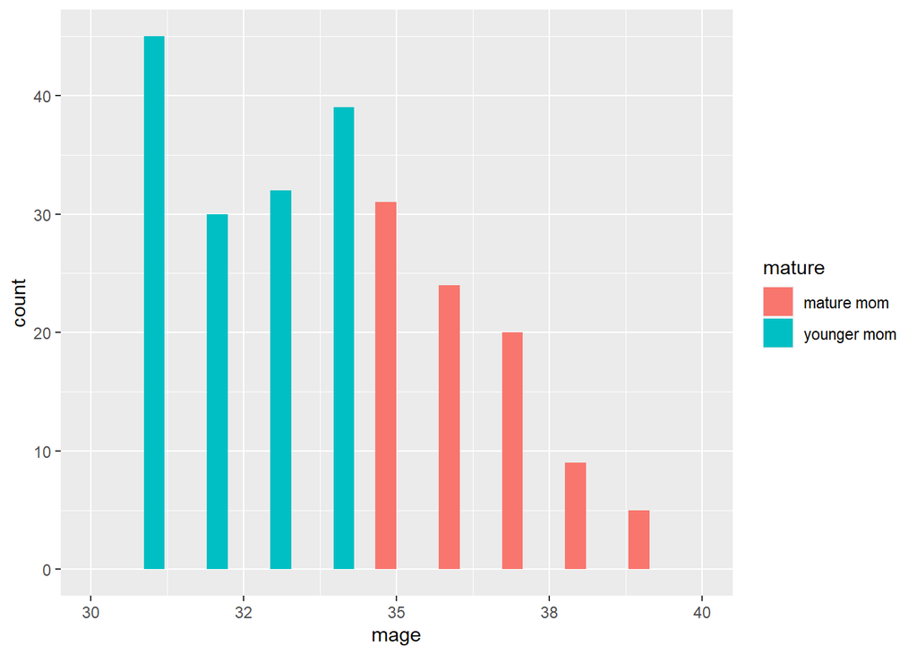

```r
ggplot(ncbirths_white, aes(x = mage, fill = mature)) +
  geom_histogram() +
  xlim(30, 40)
```

The other variable of interest is `lowbirthweight`.

12. Conduct a hypothesis test evaluating whether the proportion of low birth weight babies is higher for mature mothers. State the hypotheses, verify the conditions, run the test and calculate the p-value, and state your conclusion in context of the research question. Use $\alpha = 0.05$. If you find a significant difference, costruct a confidence interval, at the equivalent level to the hypothesis test, for the difference between the proportions of low birth weight babies between mature and younger moms, and interpret this interval in context of the data.

H0: the proportion of low birth weight babies is equal for mature and younger mothers Ha: the proportion of low birth weight babies is higher for mature mothers

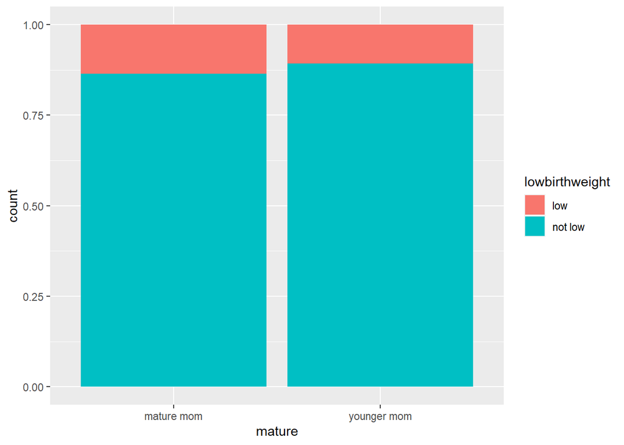

```r
ggplot(ncbirths, aes(fill = lowbirthweight, x = mature)) +
  geom_bar(position = "fill")
```

```r
m2 <- ncbirths %>%
  count(lowbirthweight, mature) %>%
  group_by(mature) %>%
  mutate(p_hat = n / sum(n))
m2$p_hat[1] - m2$p_hat[2]
```

```
## [1] 0.028
```

```r
levels(ncbirths$lowbirthweight)
```

```
## [1] "low"     "not low"
```

```r
levels(ncbirths$mature)
```

```
## [1] "mature mom"  "younger mom"
```

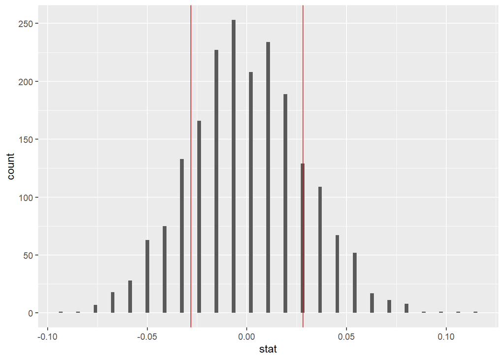

```r
boot_means <- ncbirths %>%
  specify(response = lowbirthweight, explanatory = mature, success = "low") %>%
  hypothesize(null = "independence") %>%
  generate(reps = 2000, type = "permute") %>%
  calculate(stat = "diff in props", order = c("mature mom", "younger mom"))

ggplot(data = boot_means, aes(x = stat)) +
  geom_bar() +
  geom_vline(xintercept = -.0281, color = "red") +
  geom_vline(xintercept = .0281, color = "red")
```

```r
a <- boot_means %>%
  filter(stat <= -.0281)
nrow(a)
```

```
## [1] 326
```

```r
a %>%
  summarise(p_value = n() / 2000)
```

```
## # A tibble: 1 x 1
##   p_value
##     <dbl>
## 1   0.163
```

```r
# not significant

# calculate bootstrap (altough not necessary)
boot_means_str <- ncbirths %>%
  specify(response = lowbirthweight, explanatory = mature, success = "low") %>%
  generate(reps = 2000, type = "bootstrap") %>%
  calculate(stat = "diff in props", order = c("mature mom", "younger mom"))
mean(boot_means_str$stat)
```

```
## [1] 0.027
```

```r
boot_means_str %>%
  summarize(lower_bound = quantile(stat, 0.025),
            upper_bound = quantile(stat, 0.975))
```

```
## # A tibble: 1 x 2
##   lower_bound upper_bound
##         <dbl>       <dbl>
## 1     -0.0332      0.0897
```

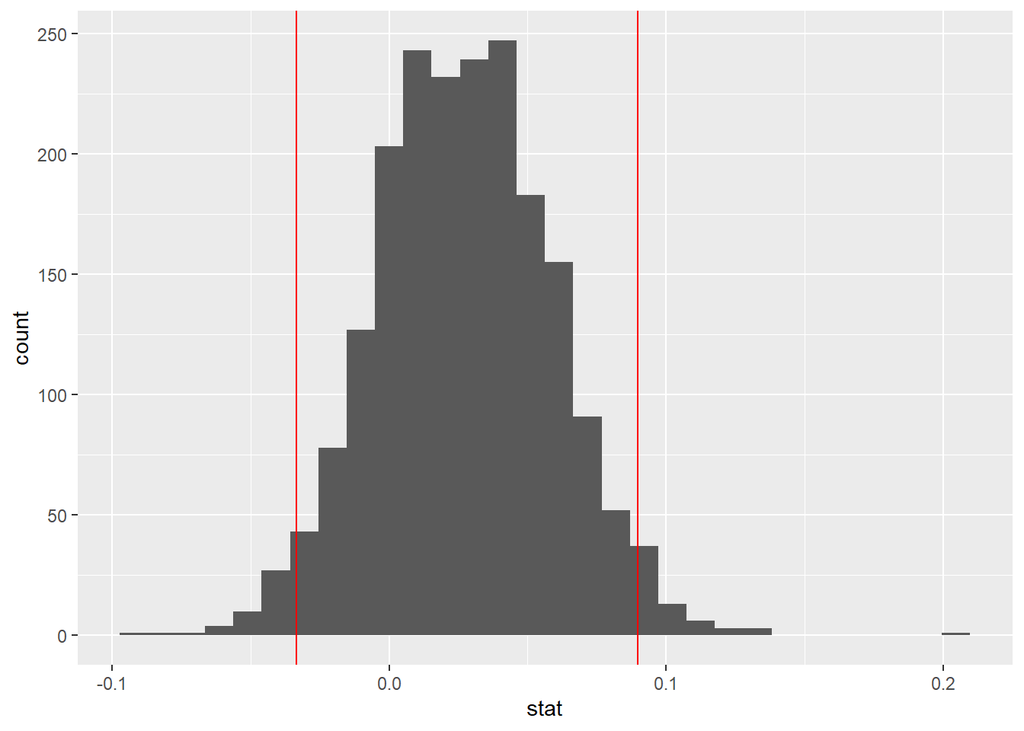

```r
ggplot(data = boot_means_str, aes(x = stat)) +
  geom_histogram() +
  geom_vline(xintercept = -.0336, color = "red") +
  geom_vline(xintercept = .0897, color = "red")
```

```r
# zero is within the confidence interval, so no significant difference in lowbirthweight for mature moms


a <- chisq.test(x = ncbirths$lowbirthweight, y = ncbirths$mature)
a
```

```
##
##  Pearson's Chi-squared test with Yates' continuity correction
##
## data:  ncbirths$lowbirthweight and ncbirths$mature
## X-squared = 0.7, df = 1, p-value = 0.4
```